# Report_omiche

Roberto Scardigno

6/10/2021

# Analisi statistica e di Enrichment su varie omiche per il monitoraggio degli effetti della Streptozocina e dell’insulina su vari campioni di ratti.

Le omiche considerate sono: metabolomica, RNA e miRNA. L’analisi è stata effettuata su: * un gruppo a cui è stata somministrata Streptozocina; * un gruppo a cui è stata somministrata Inuslina; * un gruppo di controllo (a cui non è stato somministrato niente). I distretti anatomici considerati sono stati: * Cervelletto; * Corteccia; * Ipotalamo; * Ippocampo. In alcune omiche erano presenti altri tessuti come cuore, reni, ecc… che sono stati esclusi dall’analisi complessiva.

Il workflow, per tutte le omiche, è pressochè identico, seppur effettuato con metodiche diverse, in quanto dati provenienti da ambienti diversi vanno trattati differentemente. In dettaglio è stato effettuato: 1. Lettura del dataset da file e divisione per distretto anatomico; 2. Pre-processing del dataset per eliminare eventuali campioni o feature non utilizzabili; 3. Trasformazione logaritmica e normalizzazione; 4. Analisi statistica con LIMMA; 5. PCA esplorativa; 6. Enrichment dei dati.

N.B. Alcune omiche hanno richiesto degli step intermedi per un’analisi completa che verranno commentate in seguito

Librerie per analisi con LIMMA

```r
library("readr")
library("BiocManager")
library("biomaRt")
library("RSQLite")
library("rlist")
library("stats")
library("limma")
library("edgeR")
library("mixOmics")
library("ggplot2")
library("gridExtra")
```

Librerie per Enrichment dei dati

```r
library(topGO)
library(tidyverse)
library(dplyr)
library(Rgraphviz)
library(clusterProfiler)
library(enrichplot)
library(DOSE)
library(FELLA)
library(rbioapi)
library(ComplexHeatmap)
library(circlize)
library(org.Rn.eg.db)
```

## Omica 1: RNA

Questa omica prende in considerazione i dati ottenuti dal sequenziamento tramite NGS, in grado di rivelare la presenza e la quantità di RNA di un determinato campione biologico in un determinato momento. Il NGS è stato effettuato tramite una macchina Agilent.

### Caricamento Dataset

```r
dataset = read_tsv("mRNA/GENE EXPRESSION RAT GNONI.txt")
```

### Pre-processing dei dati

I dati genetici vengono recuperati da Ensembl.org tramite BioMart

```r
ensembl = useMart(biomart="ensembl", dataset="rnorvegicus_gene_ensembl")
dictionary = getBM(attributes = c('ensembl_gene_id', 'external_gene_name', 'description', 'agilent_wholegenome_4x44k_v3'), mart = ensembl)
full_dataset <- merge(dataset, dictionary, by.x = "ProbeName", by.y = "agilent_wholegenome_4x44k_v3")
```

Eliminazione dei geni non annotati

```r
full_dataset <- full_dataset[!(is.na(full_dataset$external_gene_name) | full_dataset$external_gene_name==""), ]
```

Eliminazione dei long non-coding RNA

```r
full_dataset <- full_dataset[grep("LOC", full_dataset$external_gene_name, invert = TRUE), ]
```

Dopo questa fase sono ancora presenti Probes che molto probabilmente sono non-coding RNA ma non sono ancora ben identificati

Viene effettuata una media dei dati delle Probes associate ad uno stesso gene

```r
dataset_filtered <- aggregate(full_dataset[, 2:(length(full_dataset)-3)], by = list(full_dataset$ensembl_gene_id), FUN  = "mean")
colnames(dataset_filtered)[1] = "Ensembl Gene"
```

Divisione del dataset nei vari casi STZ (ratti con Streptozocina), INS (ratti con insulina) e CTRL (gruppo di controllo)

```r
dataset_ctrl_cervelletto <- dataset_filtered[ ,c(2,6,10)]
dataset_ctrl_corteccia   <- dataset_filtered[ ,c(3,7,11)]
dataset_ctrl_ipotalamo   <- dataset_filtered[ ,c(4,8,12)]
dataset_ctrl_ippocampo   <- dataset_filtered[ ,c(5,9,13)]

dataset_ins_cervelletto  <- dataset_filtered[ ,c(14,18,22)]
dataset_ins_corteccia    <- dataset_filtered[ ,c(15,19,23)]
dataset_ins_ipotalamo    <- dataset_filtered[ ,c(16,20,24)]
dataset_ins_ippocampo    <- dataset_filtered[ ,c(17,21,25)]

dataset_stz_cervelletto  <- dataset_filtered[ ,c(26,30,34,38,42,46)]
dataset_stz_corteccia    <- dataset_filtered[ ,c(27,31,35,39,43,47)]
dataset_stz_ipotalamo    <- dataset_filtered[ ,c(28,32,36,40,44,48)]
dataset_stz_ippocampo    <- dataset_filtered[ ,c(29,33,37,41,45,49)]
```

### Analisi con LIMMA e PCA esplorativa

L’analisi con LIMMA permette di identificare la probabilità che la differenza di espressione genica tra gruppo 1 e gruppo 2 sia statisticamente significativa, restituendo un p-Value che successivamente verrà corretto data la mole di confronti fatti. Infine, la PCA consentirà di visualizzare, la distribuzione dei campioni considerati in uno spazio bidimensionale.

```r
contrasts_to_do <- list(c("dataset_ctrl_cervelletto", "dataset_ins_cervelletto"),c("dataset_ctrl_cervelletto", "dataset_stz_cervelletto"),c("dataset_ins_cervelletto", "dataset_stz_cervelletto"),
                        c("dataset_ctrl_corteccia", "dataset_ins_corteccia"),c("dataset_ctrl_corteccia", "dataset_stz_corteccia"),c("dataset_ins_corteccia", "dataset_stz_corteccia"),
                        c("dataset_ctrl_ipotalamo", "dataset_ins_ipotalamo"),c("dataset_ctrl_ipotalamo", "dataset_stz_ipotalamo"),c("dataset_ins_ipotalamo", "dataset_stz_ipotalamo"),
                        c("dataset_ctrl_ippocampo", "dataset_ins_ippocampo"),c("dataset_ctrl_ippocampo", "dataset_stz_ippocampo"),c("dataset_ins_ippocampo", "dataset_stz_ippocampo"))
```

Per ogni iterazione viene effettuato un test delle ipotesi che produce un p-Value e un p-Value corretto tramite False Discovery Rate, in particolare tramite il metodo di Benjamini-Hochberg

```r
for (i in 1:length(contrasts_to_do)){
  dataset_to_fit <- cbind(eval(as.name(contrasts_to_do[[i]][1])), eval(as.name(contrasts_to_do[[i]][2])))
  rownames(dataset_to_fit) <- dataset_filtered$'Ensemble Gene'
  group <- as.factor(c(rep(1, length(eval(as.name(contrasts_to_do[[i]][1])))), rep(2, length(eval(as.name(contrasts_to_do[[i]][2]))))))
  design <- model.matrix(~0 + group)
  contrasts.matrix <- makeContrasts(group2-group1, levels=colnames(design))
  fit <- lmFit(dataset_to_fit, design)
  fit2 <- contrasts.fit(fit, contrasts.matrix)
  fit2 <- eBayes(fit2)
  results <- decideTests(fit2)

  # Salvataggio dei report
  jpeg(paste("volcanoplot", i, ".jpeg", sep = "_"), width = 700, height = 500)
  volcanoplot(fit2)
  dev.off()

  write.fit(fit2, file = paste("Report", i, contrasts_to_do[[i]][2], "VS", contrasts_to_do[[i]][1], ".txt", sep = "_"), sep = ",", adjust = "BH", results = results)

  # PCA Esplorativa
  pca_dataset <- t(dataset_to_fit)
  colnames(pca_dataset) <- rownames(dataset_to_fit)
  pca_results <- pca(pca_dataset, ncomp = 6)
  jpeg(paste("mRNA_pcaIndiv", contrasts_to_do[[i]][1], contrasts_to_do[[i]][2], ".jpeg", sep = "_"), width = 700, height = 500)
  plotIndiv(pca_results, group = group, title = 'Individui sulle componenti 1 - 2')
  dev.off()
}
```

### Esempio: Confronto dei dati tra STZ e CTRL nella corteccia

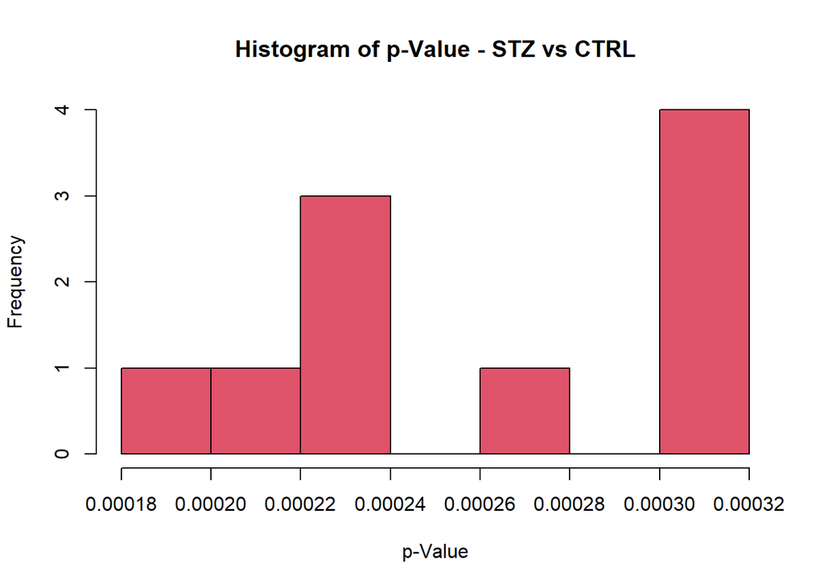

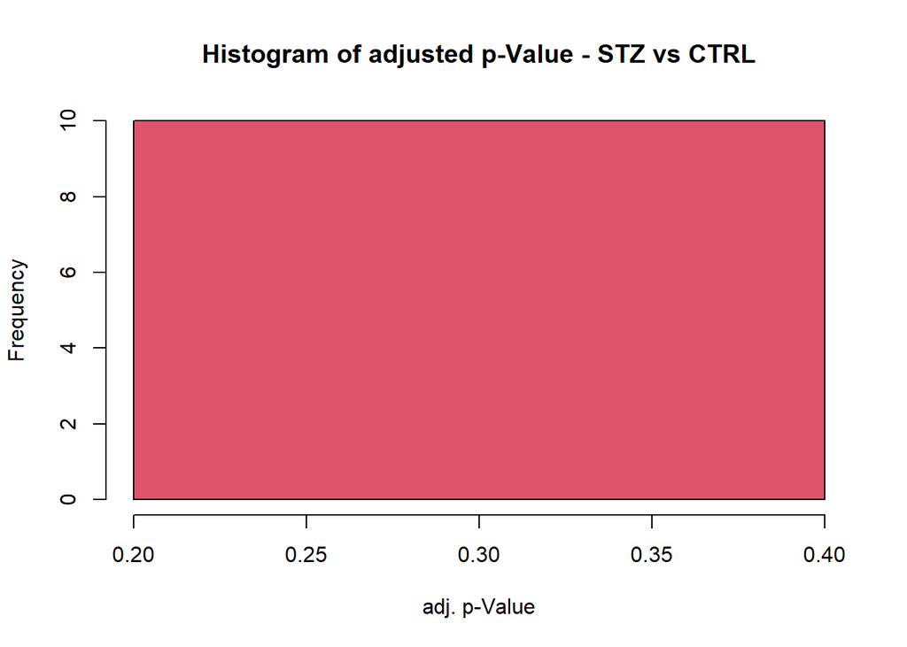

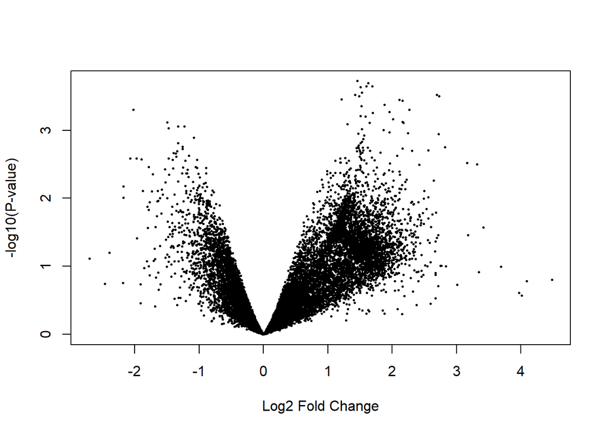

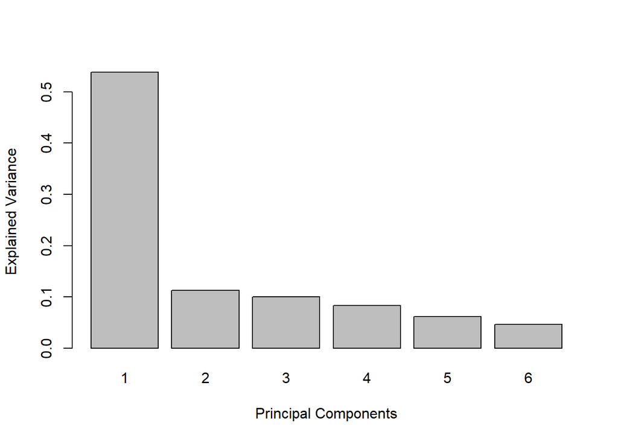

```r
for (i in 5){
  dataset_to_fit <- cbind(eval(as.name(contrasts_to_do[[i]][1])), eval(as.name(contrasts_to_do[[i]][2])))
  rownames(dataset_to_fit) <- dataset_filtered$'Ensembl Gene'
  group <- as.factor(c(rep(1, length(eval(as.name(contrasts_to_do[[i]][1])))), rep(2, length(eval(as.name(contrasts_to_do[[i]][2]))))))
  design <- model.matrix(~0 + group)
  contrasts.matrix <- makeContrasts(group2-group1, levels=colnames(design))
  fit <- lmFit(dataset_to_fit, design)
  fit2 <- contrasts.fit(fit, contrasts.matrix)
  fit2 <- eBayes(fit2)
  limma_table = topTable(fit2)
  hist(limma_table$P.Value, col=10, main = "Histogram of p-Value - STZ vs CTRL", xlab= "p-Value")
  hist(limma_table$adj.P.Val, col=10, main = "Histogram of adjusted p-Value - STZ vs CTRL", xlab= "adj. p-Value")

  volcanoplot(fit2)

   # PCA Esplorativa
  pca_dataset <- t(dataset_to_fit)
  colnames(pca_dataset) <- rownames(dataset_to_fit)
  pca_results <- pca(pca_dataset, ncomp = 6)
  pca_results
  plot(pca_results)
}
```

### Enrichment dei dati tramite GO

Analisi effettuata sull’esempio precedente: STZ vs CTRL nella corteccia

Recupero tramite BioMart delle funzioni associate ai singoli geni oggetti dello studio e caricamento del dataset In prima istanza viene scaricato il dizionario completo dei geni individuati nel Rattus Norvegicus, soggetto dello studio; dopodichè viene caricato un report contenente i geni e i rispettivi p-value per essere valutati. Grazie all’enrichment è possibile individuare, tramite varie tecniche (grafo, bar plot, ecc…), il significato di ogni gene e gli effetti che una sua sovraespressione/sottespressione può produrre. In questo primo enrichment dei dati viene utilizzata la Gene Ontology che, tramite un grafo, consente di ricostruire le varie connessioni che sono presenti tra i vari geni, sottoforma di processi biologici. Per semplificazione in questa prima parte non vengono considerate le altre 2 tipologie: funzioni molecolari e componenti cellulari.

```r
GOdictionary_full = getBM(attributes = c('ensembl_gene_id', 'go_id', 'name_1006','definition_1006', 'entrezgene_id'), mart = ensembl)
dataset = read.csv2("Report_5_dataset_stz_corteccia_VS_dataset_ctrl_corteccia_.csv", row.names = 1)
```

Rimozione dei geni non associati e preparazione del dataset. Vengono considerati solo i geni che hanno un p-Value minore a 0.05

```r
GOdictionary_full <- GOdictionary_full[GOdictionary_full$go_id != '',]
GOdictionary <- GOdictionary_full %>% dplyr::select('ensembl_gene_id', 'go_id')

geneID2GO <- by(GOdictionary$go_id, GOdictionary$ensembl_gene_id, function(x) as.character(x))

geneNames <- names(geneID2GO)
data_to_enrich <- subset(dataset, P.Value < '0.05')
geneList <- factor(as.integer(geneNames %in% row.names(data_to_enrich)))
names(geneList) <- geneNames
RAT.GO.Obj <- new("topGOdata", ontology='BP', allGenes = geneList, annot = annFUN.gene2GO, gene2GO = geneID2GO)
```

```
##
## Building most specific GOs .....
```

```
##  ( 11700 GO terms found. )
```

```
##
## Build GO DAG topology ..........
```

```
##  ( 15360 GO terms and 35057 relations. )
```

```
##
## Annotating nodes ...............
```

```
##  ( 17707 genes annotated to the GO terms. )
```

Il test di Fisher permette di individuare quali geni, tra quelli già selezionati, sono, nei processi biologici, statisticamente significativi.

Test esatto di Fisher (GO Enrichment)

```r
resultFisher <- runTest(RAT.GO.Obj, algorithm = "classic", statistic = "fisher")
```

```
##
##           -- Classic Algorithm --
##
##       the algorithm is scoring 8499 nontrivial nodes
##       parameters:
##           test statistic: fisher
```

```r
resultFisher
```

```
##
## Description:
## Ontology: BP
## 'classic' algorithm with the 'fisher' test
## 15360 GO terms scored: 140 terms with p < 0.01
## Annotation data:
##     Annotated genes: 17707
##     Significant genes: 2247
##     Min. no. of genes annotated to a GO: 1
##     Nontrivial nodes: 8499
```

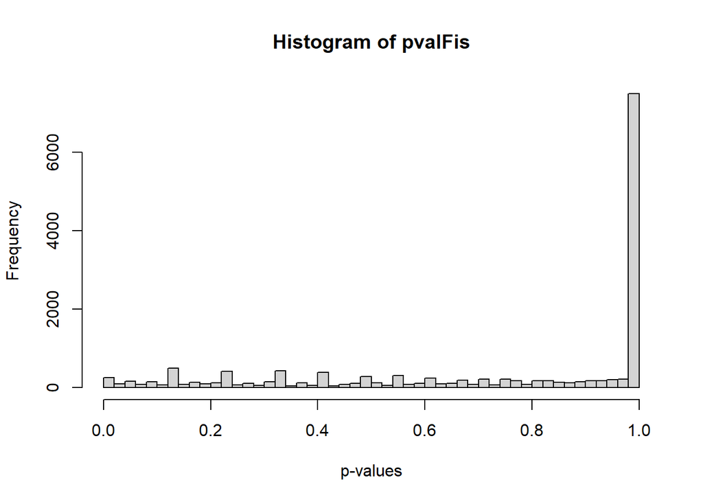

```r
pvalFis <- score(resultFisher)
hist(pvalFis, 50, xlab = "p-values")
```

```r
geneData(resultFisher)
```

```
##   Annotated Significant    NodeSize    SigTerms
##       17707        2247           1        8499
```

Visualizzazione dei risultati tramite grafo aciclico

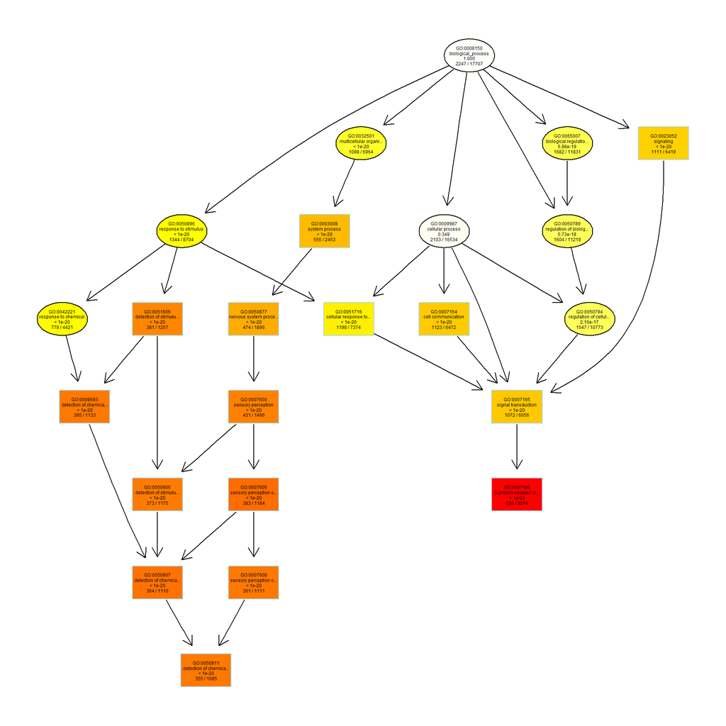

```
## $dag
## A graphNEL graph with directed edges
## Number of Nodes = 23
## Number of Edges = 34
##
## $complete.dag
## [1] "A graph with 23 nodes."
```

```r
allRes <- GenTable(RAT.GO.Obj, classic = resultFisher,orderBy = "weight", ranksOf = "classic", topNodes = 20)
goID <- allRes[10, "GO.ID"]
showSigOfNodes(RAT.GO.Obj, score(resultFisher), firstSigNodes = 15, useInfo = 'all')
```

```r
printGraph(RAT.GO.Obj, resultFisher, firstSigNodes = 23, fn.prefix = "tGO", useInfo = "all", pdfSW = TRUE)
```

```
## tGO_classic_23_all  --- no of nodes:  58
```

### Analisi dei geni sovra/sotto-espressi tramite GSEA (Gene Set Enrichment Analysis) nella Gene Ontology

In questa parte di analisi, non vengono più considerati i p-Value estratti con LIMMA, ma la sovra/sotto-espressione di ogni gene. In questo caso si identificano i geni sovra-espressi come coloro che hanno un log Fold-Change maggiore a 1.5, mentre i geni sotto-espressi come coloro che hanno un log Fold-Change minore a -1.5.

```r
# L'analisi GSEA richiede di lavorare sugli EntrezID (banca dati del NCBI) e non con gli Ensemble
EntrezIDs <- unique(GOdictionary_full %>% dplyr::select('ensembl_gene_id', 'entrezgene_id'))
EntrezIDs <- EntrezIDs %>% filter(entrezgene_id != "")
dataset <- rownames_to_column(dataset, var = "EnsemblID")
dataset_joined <- right_join(dataset, EntrezIDs, by = c("EnsemblID" = "ensembl_gene_id"), copy = FALSE, suffix = c(".x", ".y"))
geneListGO <- data.frame(EntrezID = dataset_joined[ , "entrezgene_id"] , LogFC = dataset_joined[ , "logFC"])
geneListGO_selected <- geneListGO %>% filter(LogFC > 1.5 | LogFC < -1.5)
genes_entrezIDs <- as.character(geneListGO_selected[ , 1])

# Over-representation Test su Processi Biologici
ego <- enrichGO(gene          = genes_entrezIDs,
                #universe      = as.character(geneListGO[, "EntrezID"]),
                OrgDb         = org.Rn.eg.db,
                keyType = "ENTREZID",
                ont           = "BP",
                pAdjustMethod = "BH",
                pvalueCutoff  = 0.1,
                qvalueCutoff  = 0.1,
                readable      = FALSE)
```

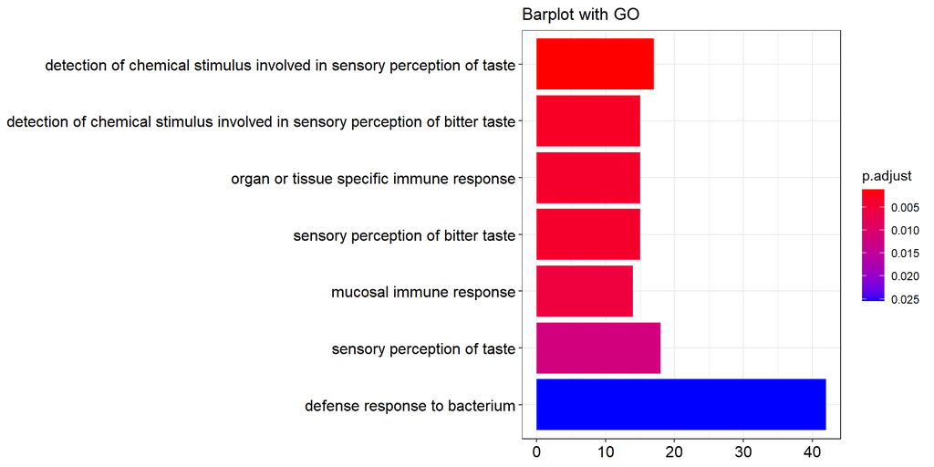

```r
if (ego@result[1,"p.adjust"] < 0.1){
  barplot(ego, showCategory=15) + ggtitle("Barplot with GO")
}
```

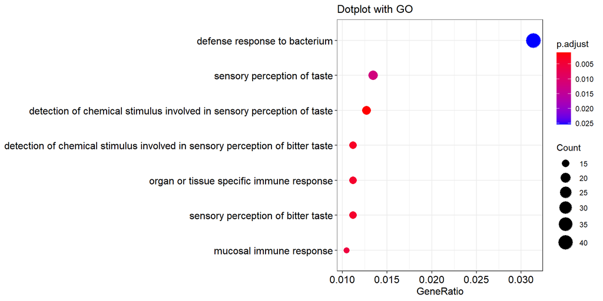

```r
if (ego@result[1,"p.adjust"] < 0.1){
  dotplot(ego, showCategory=30) + ggtitle("Dotplot with GO")
} else {
  print("L'analisi di Enrichment per processi biologici non può essere effettuata")
}
```

```r
# Over-representation Test su Funzioni Molecolari
ego2 <- enrichGO(gene          = genes_entrezIDs,
                #universe      = as.character(geneListGO[, "EntrezID"]),
                OrgDb         = org.Rn.eg.db,
                keyType = "ENTREZID",
                ont           = "MF",
                pAdjustMethod = "BH",
                pvalueCutoff  = 0.1,
                qvalueCutoff  = 0.1,
                readable      = FALSE)
```

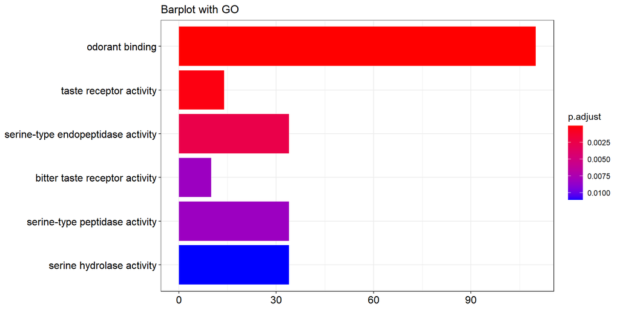

```r
if (ego2@result[1,"p.adjust"] < 0.1){
  barplot(ego2, showCategory=15) + ggtitle("Barplot with GO")
}
```

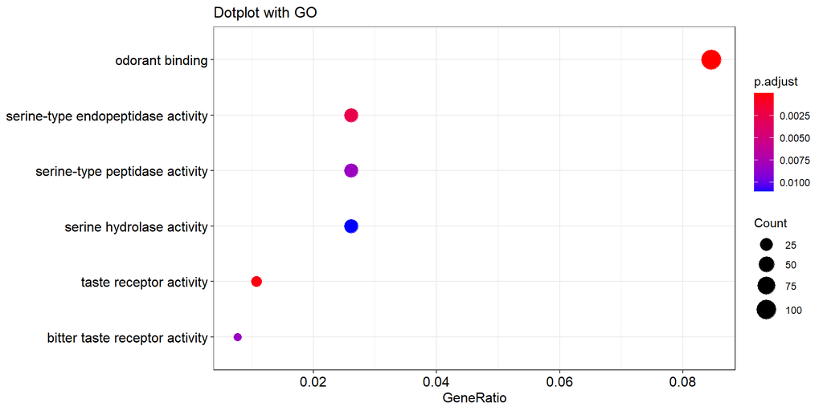

```r
if (ego2@result[1,"p.adjust"] < 0.1){
  dotplot(ego2, showCategory=30) + ggtitle("Dotplot with GO")
} else {
  print("L'analisi di Enrichment per funzioni molecolari non può essere effettuata")
}
```

```r
# Over-representation Test su Componenti Cellulari
ego3 <- enrichGO(gene          = genes_entrezIDs,
                #universe      = as.character(geneListGO[, "EntrezID"]),
                OrgDb         = org.Rn.eg.db,
                keyType = "ENTREZID",
                ont           = "CC",
                pAdjustMethod = "BH",
                pvalueCutoff  = 0.1,
                qvalueCutoff  = 0.1,
                readable      = FALSE)
```

```r
if (ego3@result[1,"p.adjust"] < 0.1){
  barplot(ego3, showCategory=15) + ggtitle("Barplot with GO")
}
```

```r
if (ego3@result[1,"p.adjust"] < 0.1){
  dotplot(ego3, showCategory=30) + ggtitle("Dotplot with GO")
} else {
  print("L'analisi di Enrichment per componenti cellulari non può essere effettuata")
}
```

```
## [1] "L'analisi di Enrichment per componenti cellulari non può essere effettuata"
```

## Omica 2: mi-RNA

I microRNA sono piccole molecole endogene non codificanti. Sono lunghi circa 20-22 nucleotidi e sono principalmente attivi nella regolazione genica a livello trascrizionale e post-trascrizionale.

Anche per questa omica viene fatta un’iniziale analisi per individuare la significatività della differenza di espressione genica tra i vari gruppi presi in esame ed, infine, viene effettuata un analisi di Enrichment.

### Caricamento dataset

```r
# Questi dati vengono considerati già log-trasformati
raw_counts <- read.delim("miRNA/miRNA EXPRESSION RAT GNONI.txt", row.names = 1)
```

### Pre-processing

```r
# Elimino le righe non coinvolte nell'analisi
temp_raw_counts <- data.frame(t(raw_counts))
raw_counts <- data.frame(t(temp_raw_counts %>% dplyr::select(contains("rno.miR"))))
```

```r
# Divisione del dataset per parte anatomica e normalizzazione tramite z-score
dataset_cervelletto <- t(scale(raw_counts %>% dplyr::select(contains("CERVELLETTO"))))
dataset_corteccia   <- t(scale(raw_counts %>% dplyr::select(contains("CORTECCIA"))))
dataset_ipotalamo   <- t(scale(raw_counts %>% dplyr::select(contains("IPOTALAMO"))))
dataset_ippocampo   <- t(scale(raw_counts %>% dplyr::select(contains("IPPOCAMPO"))))
```

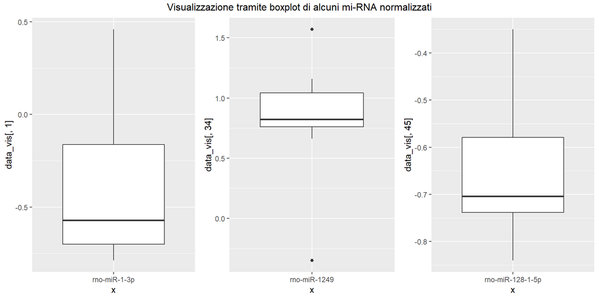

```r
# Visualizzazione di alcuni dati normalizzati tramite boxplot
data_vis <- dataset_cervelletto
bp1 <- ggplot(data.frame(data_vis[,1]), aes(x="rno-miR-1-3p", y=data_vis[,1])) +
  geom_boxplot()
bp2 <- ggplot(data.frame(data_vis[,34]), aes(x="rno-miR-1249", y=data_vis[,34])) +
  geom_boxplot()
bp3 <- ggplot(data.frame(data_vis[,45]), aes(x="rno-miR-128-1-5p", y=data_vis[,45])) +
  geom_boxplot()
grid.arrange(bp1, bp2, bp3, nrow = 1, top = "Visualizzazione tramite boxplot di alcuni mi-RNA normalizzati")
```

### Analisi con LIMMA

```r
ctrl_check <- "CTRL"
stz_check  <- "STZ"
ins_check  <- "INS"
dataset_list <- c("dataset_cervelletto", "dataset_corteccia", "dataset_ipotalamo", "dataset_ippocampo")
for (j in dataset_list)
{
  dataset_to_analyze <- as.data.frame(t(eval(parse(text = j))))
  for (i in 1:3)
  {
    if (i == 1)
    {
      check_1 <- ctrl_check
      check_2 <- ins_check
    }
    else if (i == 2)
    {
      check_1 <- stz_check
      check_2 <- ctrl_check
    }
    else if (i == 3)
    {
      check_1 <- stz_check
      check_2 <- ins_check
    }
    temp_dataset <- dataset_to_analyze %>% dplyr::select(contains(check_1) | contains(check_2))
    len_1 <- length(dplyr::select(dataset_to_analyze, dplyr::contains(check_1))) # Verifico quanti casi sono presenti per il primo gruppo
    len_2 <- length(dplyr::select(dataset_to_analyze, dplyr::contains(check_2))) # Verifico quanti casi sono presenti per il secondo gruppo
    group <- as.factor(c(rep(1, len_1), rep(2, len_2)))
    design <- model.matrix(~0 + group)
    contrasts.matrix <- makeContrasts(group2-group1, levels=colnames(design))
    fit <- lmFit(temp_dataset, design)
    fit2 <- contrasts.fit(fit, contrasts.matrix)
    fit2 <- eBayes(fit2)
    limma_table <- topTable(fit2)
    head(temp_dataset) # Sommario delle prime features analizzate
    limma_table # Risultati dell'analisi LIMMA
    hist(limma_table$P.Value, col=10, main = paste("Histogram of p-Value -", check_1, "vs", check_2), xlab= "p-Value")
    hist(limma_table$adj.P.Val, col=10, main = paste("Histogram of adjusted p-Value -", check_1, "vs", check_2), xlab= "adj. p-Value")
    volcanoplot(fit2)

    # PCA esplorativa
    pca_dataset <- t(temp_dataset)
    colnames(pca_dataset) <- rownames(temp_dataset)
    pca_results <- pca(pca_dataset, ncomp = 6)
    pca_results
    # Plot della distribuzione della varianza dopo PCA
    plot(pca_results)
    # Plot che mostra quali metaboliti pesano maggiormente sulla varianza della componente 1
    plotLoadings(pca_results, title = 'Pesi sulla componente 1')
    # Plot della distribuzione spaziale, tra le due componenti principali rilevate dalla PCA, dei casi presi in esame
    plotIndiv(pca_results, group = group, title = 'Individui sulle componenti 1 - 2')

    # Salvataggio dati
    jpeg(paste("volcanoplot_", j, check_1, check_2, ".jpeg", sep = "_"), width = 700, height = 500)
    volcanoplot(fit2)
    dev.off()

    write.fit(fit2, file = paste("Report", j, check_1, "VS", check_2, ".txt", sep = "_"), sep = ";", adjust = "BH")

    jpeg(paste("pcaIndiv", j, check_1, check_2, ".jpeg", sep = "_"), width = 700, height = 500)
    plotIndiv(pca_results, group = group, title = 'Individui sulle componenti 1 - 2')
    dev.off()
  }
}
```

### Esempio: Risultati tra STZ e CTRL nel cervelletto

```r
example_dataset <- as.data.frame(t(dataset_cervelletto)) %>% dplyr::select(dplyr::contains("STZ") | dplyr::contains("CTRL"))
len_1 <- length(dplyr::select(example_dataset, dplyr::contains("STZ"))) # Verifico quanti casi sono presenti per il primo gruppo
len_2 <- length(dplyr::select(example_dataset, dplyr::contains("CTRL"))) # Verifico quanti casi sono presenti per il secondo gruppo
group <- as.factor(c(rep(1, len_1), rep(2, len_2)))
design <- model.matrix(~0 + group)
contrasts.matrix <- makeContrasts(group2-group1, levels=colnames(design))
fit <- lmFit(example_dataset, design)
fit2 <- contrasts.fit(fit, contrasts.matrix)
fit2 <- eBayes(fit2)
limma_table <- topTable(fit2)
head(example_dataset) # Sommario delle prime features analizzate
```

```
##                 STZ.1.SHORT.CERVELLETTO.txt.gTotalProbeSignal
## rno.miR.1.3p                                        0.4588619
## rno.miR.1.5p                                       -0.7352677
## rno.miR.100.3p                                     -0.7352677
## rno.miR.100.5p                                      1.6737087
## rno.miR.101a.3p                                     1.9976797
## rno.miR.101a.5p                                    -0.7352677
##                 STZ.2.SHORT.CERVELLETTO.txt.gTotalProbeSignal
## rno.miR.1.3p                                       -0.3501805
## rno.miR.1.5p                                        2.1498841
## rno.miR.100.3p                                     -0.3501805
## rno.miR.100.5p                                     -0.3501805
## rno.miR.101a.3p                                    -0.3501805
## rno.miR.101a.5p                                    -0.3501805
##                 STZ.3.SHORT.CERVELLETTO.txt.gTotalProbeSignal
## rno.miR.1.3p                                       -0.5576247
## rno.miR.1.5p                                        1.2104909
## rno.miR.100.3p                                     -0.5576247
## rno.miR.100.5p                                      1.8217325
## rno.miR.101a.3p                                     2.2023185
## rno.miR.101a.5p                                    -0.5576247
##                 STZ.1.LONG.CERVELLETTO.txt.gTotalProbeSignal
## rno.miR.1.3p                                      -0.5966515
## rno.miR.1.5p                                      -0.5966515
## rno.miR.100.3p                                    -0.5966515
## rno.miR.100.5p                                     1.7780729
## rno.miR.101a.3p                                    2.0407390
## rno.miR.101a.5p                                   -0.5966515
##                 STZ.2.LONG.CERVELLETTO.txt.gTotalProbeSignal
## rno.miR.1.3p                                      -0.5864081
## rno.miR.1.5p                                      -0.5864081
## rno.miR.100.3p                                    -0.5864081
## rno.miR.100.5p                                     1.7515402
## rno.miR.101a.3p                                    2.1022853
## rno.miR.101a.5p                                   -0.5864081
##                 STZ.3.LONG.CERVELLETTO.txt.gTotalProbeSignal
## rno.miR.1.3p                                      -0.7293986
## rno.miR.1.5p                                       0.1802019
## rno.miR.100.3p                                    -0.7293986
## rno.miR.100.5p                                     1.6339211
```

[output cut: 8 more lines]

```
## rno.miR.101a.5p                                     -0.6991695
##                 CTRL.2.SHORT.CERVELLETTO.txt.gTotalProbeSignal
## rno.miR.1.3p                                        -0.5073299
## rno.miR.1.5p                                         1.2440891
## rno.miR.100.3p                                      -0.5073299
## rno.miR.100.5p                                      -0.5073299
## rno.miR.101a.3p                                      1.4582248
## rno.miR.101a.5p                                     -0.5073299
##                 CTRL.3.SHORT.CERVELLETTO.txt.gTotalProbeSignal
## rno.miR.1.3p                                         0.4029689
## rno.miR.1.5p                                        -0.7459809
## rno.miR.100.3p                                      -0.7459809
## rno.miR.100.5p                                       1.6955150
## rno.miR.101a.3p                                      1.9141997
## rno.miR.101a.5p                                     -0.7459809
```

```r
limma_table # Risultati dell'analisi LIMMA
```

```
##                        logFC   AveExpr         t      P.Value  adj.P.Val
## rno.miR.466b.2.3p  2.2547706 0.1590017  6.337211 0.0001677075 0.06570453
## rno.miR.466c.3p    2.1799796 0.1340713  6.288138 0.0001773402 0.06570453
## rno.miR.770.3p     1.1148424 0.2292525  3.203419 0.0114913076 0.67641734
## rno.miR.125b.2.3p  1.0738076 0.1714420  3.125865 0.0129738087 0.67641734
## rno.miR.423.5p     0.9163107 0.1444256  2.796543 0.0218476311 0.67641734
## rno.miR.32.3p      1.6536452 0.5429388  2.776006 0.0225752028 0.67641734
## rno.miR.483.5p     1.0573753 0.4521680  2.570045 0.0313906859 0.67641734
## rno.miR.370.3p     0.9938724 0.2428739  2.550547 0.0323882886 0.67641734
## rno.miR.16.5p     -0.6655097 2.4967061 -2.397830 0.0413893528 0.67641734
## rno.miR.9a.3p     -0.4963658 2.8248507 -2.359266 0.0440334921 0.67641734
##                            B
## rno.miR.466b.2.3p  0.3737741
## rno.miR.466c.3p    0.3412388
## rno.miR.770.3p    -2.5468389
## rno.miR.125b.2.3p -2.6412604
## rno.miR.423.5p    -3.0501227
## rno.miR.32.3p     -3.0759648
## rno.miR.483.5p    -3.3365692
## rno.miR.370.3p    -3.3613361
## rno.miR.16.5p     -3.5554963
## rno.miR.9a.3p     -3.6045046
```

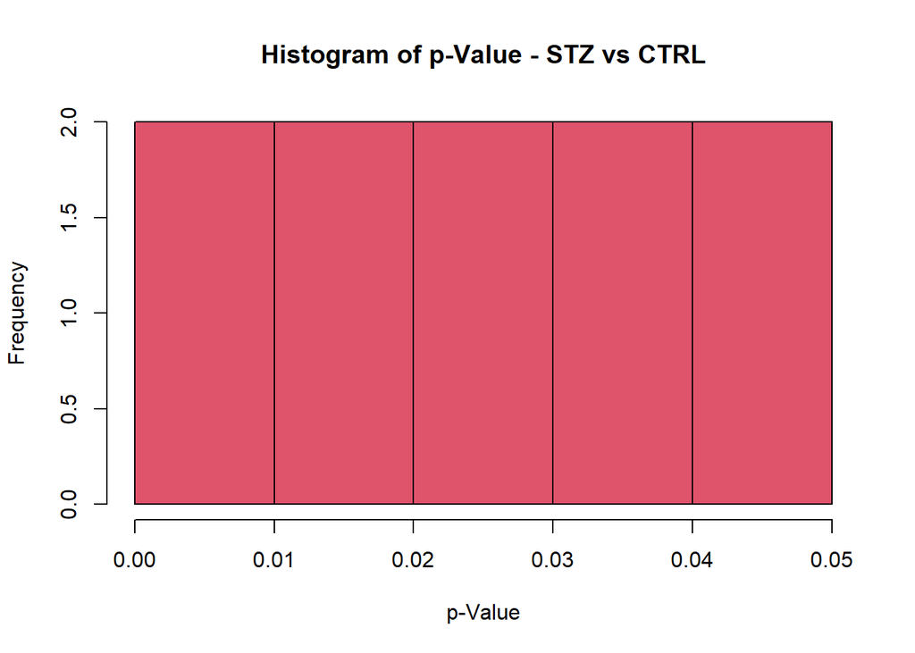

```r
hist(limma_table$P.Value, col=10, main = "Histogram of p-Value - STZ vs CTRL", xlab= "p-Value")
```

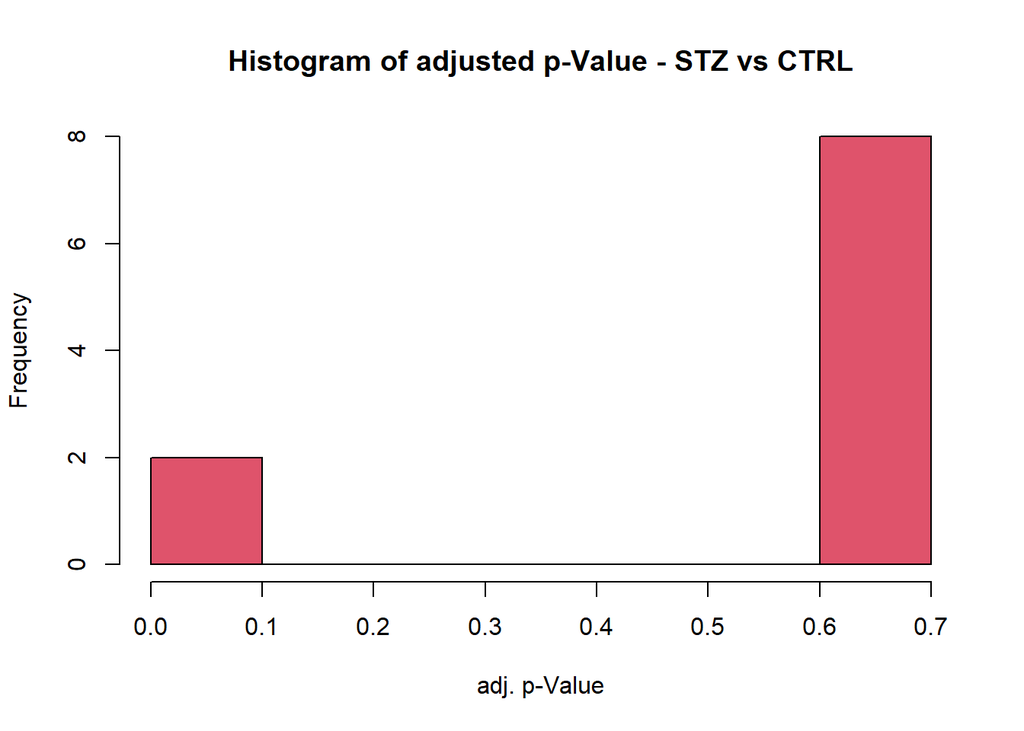

```r
hist(limma_table$adj.P.Val, col=10, main = "Histogram of adjusted p-Value - STZ vs CTRL", xlab= "adj. p-Value")
```

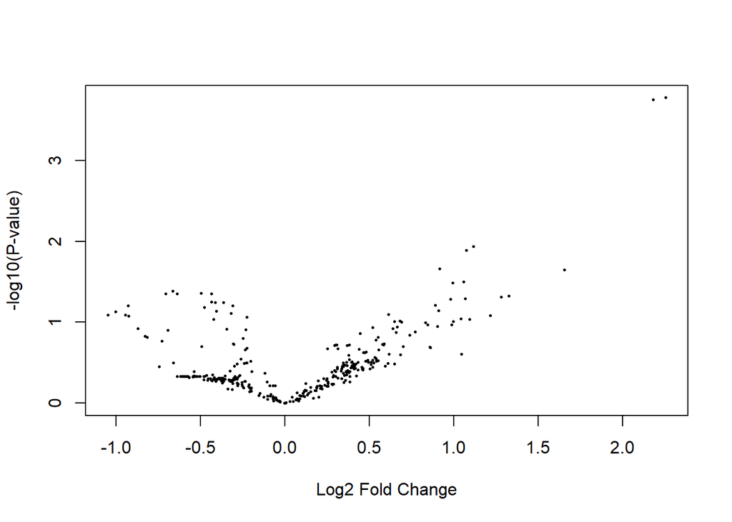

```r
volcanoplot(fit2)
```

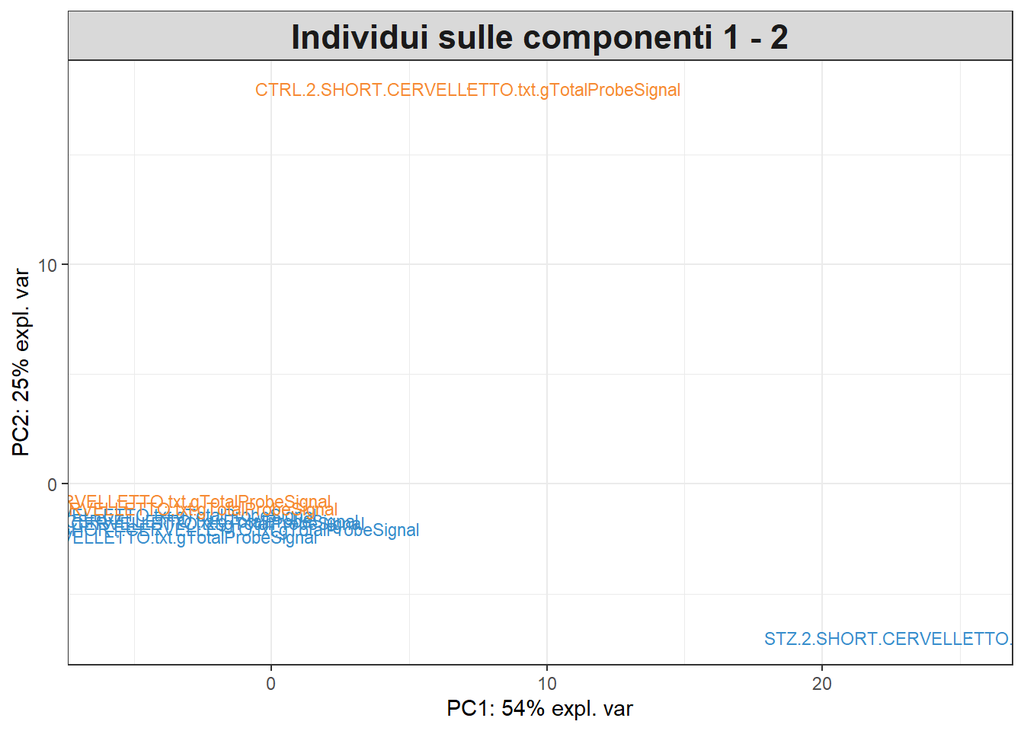

```r
pca_dataset <- t(example_dataset)
colnames(pca_dataset) <- rownames(example_dataset)
pca_results <- pca(pca_dataset, ncomp = 6)
plotIndiv(pca_results, group = group, title = 'Individui sulle componenti 1 - 2')
```

### Analisi di Enrichment su miRNA differenzialmente espressi con p-Value < 0.05 nell’ippocampo tra STZ e INS

```r
# Selezione dei miRNA di interesse
dataset_enrich <- read.csv2("Report_dataset_ippocampo_STZ_VS_INS_.txt", row.names = 1)
dataset_enrich_sel1 <- dataset_enrich %>% dplyr::filter(P.value < 0.05)
miRNAs_selected <- row.names(dataset_enrich_sel1)

# Elimino i dati non validi (non riconosciuti da miEAA)
miRNAs_selected <- gsub(".", "-", miRNAs_selected, fixed = TRUE)
miRNAs_to_remove <- c("rno-miR-3084c-3p", "rno-miR-3084c-5p", "rno-miR-3591")
miRNAs_filtered <- setdiff(miRNAs_selected, miRNAs_to_remove)

# Analisi GSEA effettuata attraverso miEAA (https://ccb-compute2.cs.uni-saarland.de/mieaa2)
mieaa_all <- rba_mieaa_enrich(test_set = miRNAs_filtered, mirna_type = "mature", test_type = "GSEA", species = "Rattus Norvegicus", categories = c("miRWalk_GO_mature", "miRWalk_Diseases_mature"))
```

```
##  -- Step 1/3: Submitting Enrichment request:
```

```
## Submitting GSEA enrichment request for 468 miRNA IDs of species Rattus norvegicus to miEAA servers.
```

```
##
##  -- Step 2/3: Checking for Submitted enrichment job's status every 5 seconds.
##     Your submitted job ID is: f13bae0c-5050-45c9-bb50-c7fb0fc3b2a4
```

```
## .
```

```
##
##  -- Step 3/3: Retrieving the results of the finished enrichment job.
```

```
## Retrieving results of submitted enrichment request with ID: f13bae0c-5050-45c9-bb50-c7fb0fc3b2a4
```

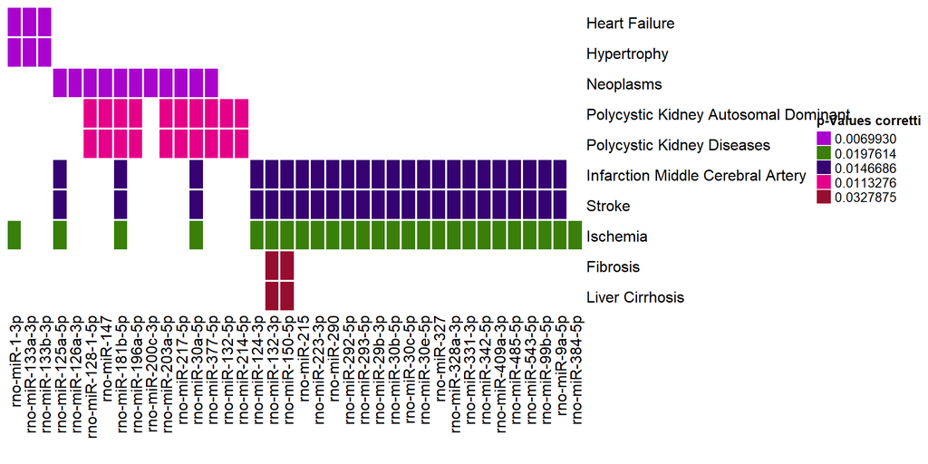

```r
# Costruzione heatmap
enrich_GO <- mieaa_all %>% dplyr::filter(X1 == "Gene Ontology (miRWalk)") %>% arrange(X5)
if (nrow(enrich_GO) > 20)
{
  enrich_GO <- enrich_GO[1:20,]
}
enrich_disease <- mieaa_all %>% dplyr::filter(X1 == "Diseases (miRWalk)") %>% arrange(X5)

# Heatmap per disease enrichment
mirna_names_d <- c()
for (i in 1:nrow(enrich_disease))
{
  temp_vector_d <- strsplit(enrich_disease[i,"X8"],"; ")
  for (j in 1:length(temp_vector_d[[1]]))
  {
    mirna_names_d <- c(mirna_names_d, temp_vector_d[[1]][[j]])
  }
}
mirna_names_unique_d <- unique(mirna_names_d) # Creo una lista dei miRNA presenti nei risultati dell'Enrichment
heatmap_dataframe_d <- data.frame(matrix(ncol = length(mirna_names_unique_d), nrow = nrow(enrich_disease)))
colnames(heatmap_dataframe_d) <- mirna_names_unique_d
rownames(heatmap_dataframe_d) <- enrich_disease[, "X2"]
for (i in 1:nrow(heatmap_dataframe_d))
{
  for (j in 1:ncol(heatmap_dataframe_d))
  {
    if (grepl(colnames(heatmap_dataframe_d)[j], enrich_disease[i,"X8"]) == TRUE)
    {
      heatmap_dataframe_d[i,j] <- enrich_disease[i, "X5"] # Riporto il p-Value all'interno della heatmap
    }
    else
    {
      heatmap_dataframe_d[i,j] <- NA
    }
  }
}

heatmap_dataframe_numeric_d <- as.matrix(heatmap_dataframe_d)
Heatmap(heatmap_dataframe_numeric_d, na_col = "white", name = "p-Values corretti", rect_gp = gpar(col = "white", lwd = 2))
```

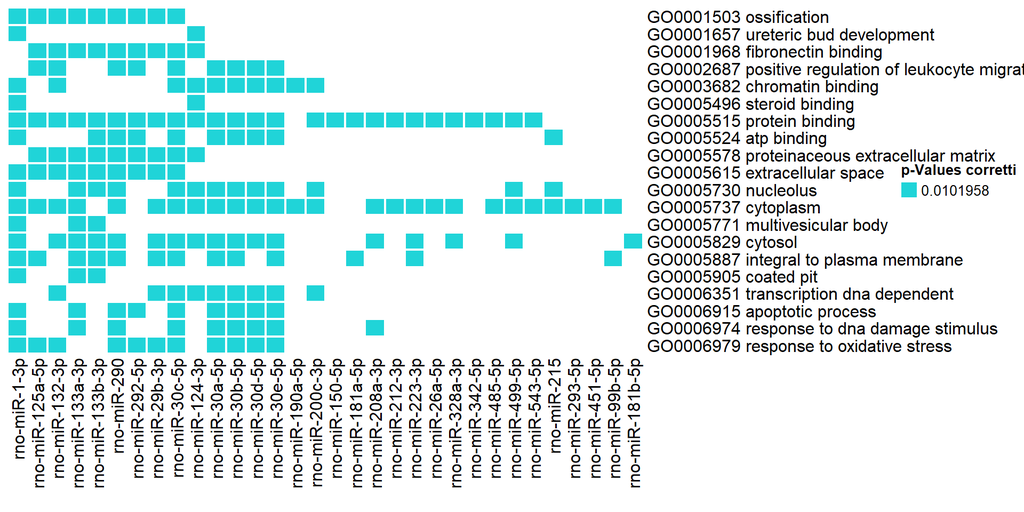

```r
# Heatmap per GO annotations enrichment
mirna_names_g <- c()
for (i in 1:nrow(enrich_GO))
{
  temp_vector_g <- strsplit(enrich_GO[i,"X8"],"; ")
  for (j in 1:length(temp_vector_g[[1]]))
  {
    mirna_names_g <- c(mirna_names_g, temp_vector_g[[1]][[j]])
  }
}
mirna_names_unique_g <- unique(mirna_names_g) # Creo una lista dei miRNA presenti nei risultati dell'Enrichment
heatmap_dataframe_g <- data.frame(matrix(ncol = length(mirna_names_unique_g), nrow = nrow(enrich_GO)))
colnames(heatmap_dataframe_g) <- mirna_names_unique_g
rownames(heatmap_dataframe_g) <- enrich_GO[, "X2"]

for (i in 1:nrow(heatmap_dataframe_g))
{
  for (j in 1:ncol(heatmap_dataframe_g))
  {
    if (grepl(colnames(heatmap_dataframe_g)[j], enrich_GO[i,"X8"]) == TRUE)
    {
      heatmap_dataframe_g[i,j] <- enrich_GO[i, "X5"] # Riporto il p-Value all'interno della heatmap
    }
    else
    {
      heatmap_dataframe_g[i,j] <- NA
    }
  }
}

heatmap_dataframe_numeric_g <- as.matrix(heatmap_dataframe_g)
Heatmap(heatmap_dataframe_numeric_g, na_col = "white", name = "p-Values corretti", rect_gp = gpar(col = "white", lwd = 2))
```

## Omica 3: Metabolomica

### Caricamento dataset e Pre-processing

```r
dataset <- read.csv2("Metabolomica/Met.csv", row.names = 1)  # Caricamento dataset
dataset = dplyr::select(dataset, !{"Additional.Info"}) # Rimozione delle informazioni meno importanti
dataset <- dataset[, grep("< LOD", dataset, invert = TRUE)]
data_splitted <- split(dataset, dataset$Material) # group_split non può essere utilizzato in quanto non mantiene i nomi dei casi (righe)
```

Divisione del dataset

```r
tbl_cerebellum <- dplyr::select(data_splitted[["Cerebellum"]], !{"Material"})
tbl_cerebCrtx <- dplyr::select(data_splitted[["Cerebral cortex"]], !{"Material"})
tbl_heart <- dplyr::select(data_splitted[["Heart"]], !{"Material"})
tbl_hypotalamus <- dplyr::select(data_splitted[["Hypotalamus"]], !{"Material"})
tbl_hyppocampus <- dplyr::select(data_splitted[["Hyppocampus"]], !{"Material"})
tbl_kidney <- dplyr::select(data_splitted[["Kidney"]], !{"Material"})
tbl_liver <- dplyr::select(data_splitted[["Liver"]], !{"Material"})
tbl_plasma <- dplyr::select(data_splitted[["Plasma"]], !{"Material"})
```

Trasformazione in scala logaritmica dei dati e normalizzazione tramite z-score

```r
dataset_list <- c("tbl_cerebellum", "tbl_cerebCrtx", "tbl_heart", "tbl_hypotalamus", "tbl_hyppocampus", "tbl_kidney", "tbl_liver", "tbl_plasma")
norm_dataset_list <- c("n_tbl_cerebellum", "n_tbl_cerebCrtx", "n_tbl_heart", "n_tbl_hypotalamus", "n_tbl_hyppocampus", "n_tbl_kidney", "n_tbl_liver", "n_tbl_plasma")
for (j in 1 : length(dataset_list))
{
  dataset_to_normalize <- eval(parse(text = dataset_list[j]))
  assign(norm_dataset_list[j], t(scale(t(log(dataset_to_normalize))))) # La funzione scale effettua l'operazione per colonne, quindi si trspone la matrice per normalizzare per samples
}
```

### Visualizzazione di alcuni dati pre- e post-normalizzazione

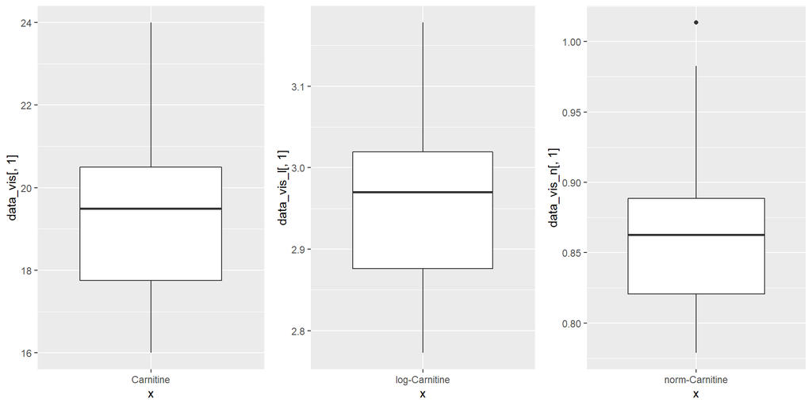

```r
data_vis <- data.frame(tbl_cerebellum[,1])
data_vis_l <- log(data.frame(tbl_cerebellum[,1]))
data_vis_n <- data.frame(n_tbl_cerebellum[, 1])

bp1 <- ggplot(data.frame(data_vis[,1]), aes(x="Carnitine", y=data_vis[,1])) +
  geom_boxplot()
bp2 <- ggplot(data.frame(data_vis_l[,1]), aes(x="log-Carnitine", y=data_vis_l[,1])) +
  geom_boxplot()
bp3 <- ggplot(data.frame(data_vis_n[,1]), aes(x="norm-Carnitine", y=data_vis_n[,1])) +
  geom_boxplot()
grid.arrange(bp1, bp2, bp3, nrow = 1)
```

### Analisi con Limma

In questo caso si vuole capire la significatività statistica tra le differenti quantità di metaboliti presenti tra i gruppi confrontati

```r
# Analisi effettuata per ogni distretto campionato
ctrl_check <- "CTRL"
stz_check  <- "STZ"
ins_check  <- "INS"
for (j in norm_dataset_list){
  dataset_to_analyze <- as.data.frame(t(eval(parse(text = j))))
  # Confronti tra INS e CTRL, CTRL e STZ, STZ e INS
  for (i in 1 : 3)
  {
    if (i == 1)
    {
      check_1 <- ctrl_check
      check_2 <- ins_check
    }
    else if (i == 2)
    {
      check_1 <- stz_check
      check_2 <- ctrl_check
    }
    else if (i == 3)
    {
      check_1 <- stz_check
      check_2 <- ins_check
    }
    temp_dataset <- dataset_to_analyze %>% dplyr::select(contains(check_1) | contains(check_2))
    group <- as.factor(c(rep(1, 4), rep(2, 4)))
    design <- model.matrix(~0 + group)
    contrasts.matrix <- makeContrasts(group2-group1, levels=colnames(design))
    fit <- lmFit(temp_dataset, design)
    fit2 <- contrasts.fit(fit, contrasts.matrix)
    fit2 <- eBayes(fit2)
    limma_table = topTable(fit2)
    hist(limma_table$P.Value, col=10, main = "Histogram of p-Value", xlab= "p-Value")
    hist(limma_table$adj.P.Val, col=10, main = "Histogram of adjusted p-Value", xlab= "adj. p-Value")

    head(temp_dataset)

    volcanoplot(fit2)

    # PCA esplorativa
    pca_dataset <- t(temp_dataset)
    colnames(pca_dataset) <- rownames(temp_dataset)
    pca_results <- pca(pca_dataset, ncomp = 6)
    pca_results
    # Plot della distribuzione della varianza dopo PCA
    plot(pca_results)
    # Plot che mostra quali metaboliti pesano maggiormente sulla varianza della componente 1
    plotLoadings(pca_results, title = 'Pesi sulla componente 1')
    # Plot della distribuzione spaziale, tra le due componenti principali rilevate dalla PCA, dei casi presi in esame
    plotIndiv(pca_results, group = group, title = 'Individui sulle componenti 1 - 2')

    # Salvataggio dati
    jpeg(paste("MET_volcanoplot_", j, check_1, check_2, ".jpeg", sep = "_"), width = 700, height = 500)
    volcanoplot(fit2)
    dev.off()

    write.fit(fit2, file = paste("MET_Report", j, check_1, "VS", check_2, ".txt", sep = "_"), sep = ";", adjust = "BH")

    jpeg(paste("MET_pcaIndiv", j, check_1, check_2, ".jpeg", sep = "_"), width = 700, height = 500)
    plotIndiv(pca_results, group = group, title = 'Individui sulle componenti 1 - 2')
    dev.off()
  }
}
```

### Esempio: Risultati dell’analisi tra gruppo STZ e INS nell’ippocampo

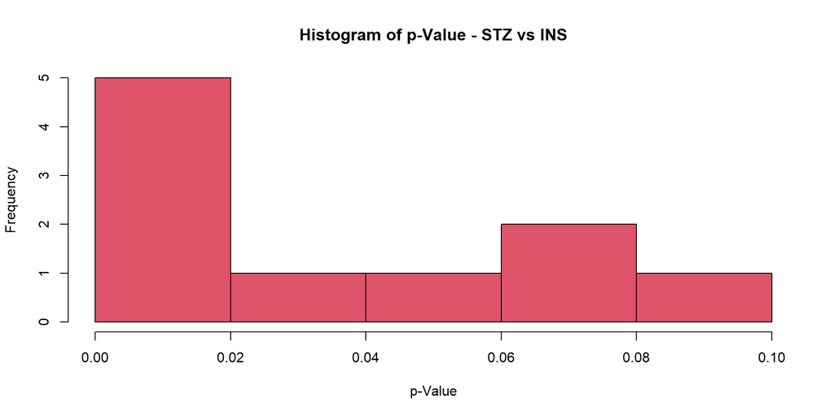

```r
example_dataset <- as.data.frame(t(n_tbl_hyppocampus)) %>% dplyr::select(contains("STZ") | contains("INS"))
group <- as.factor(c(rep(1, 4), rep(2, 4)))
design <- model.matrix(~0 + group)
contrasts.matrix <- makeContrasts(group2-group1, levels=colnames(design))
fit <- lmFit(example_dataset, design)
fit2 <- contrasts.fit(fit, contrasts.matrix)
fit2 <- eBayes(fit2)
limma_table = topTable(fit2)
hist(limma_table$P.Value, col=10, main = "Histogram of p-Value - STZ vs INS", xlab= "p-Value")
```

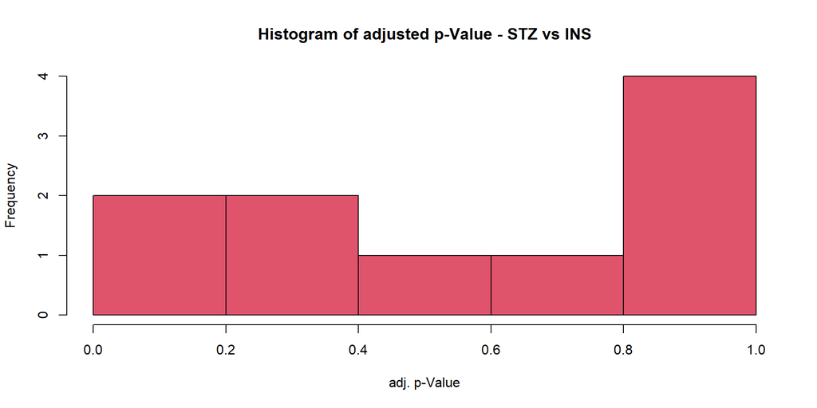

```r
hist(limma_table$adj.P.Val, col=10, main = "Histogram of adjusted p-Value - STZ vs INS", xlab= "adj. p-Value")
```

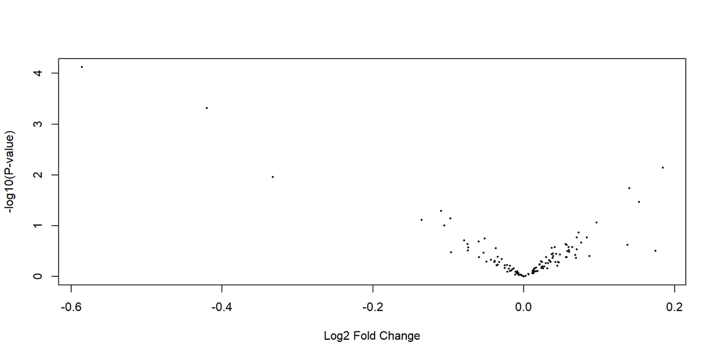

```r
volcanoplot(fit2)
```

```r
head(example_dataset)
```

```
##                                            46  STZ SHORT HPC 64 STZ SHORT  HPC
## Carnitine                                          0.8235568         0.7683187
## Acetylcarnitine                                    0.4183770         0.3061241
## Malonylcarnitine..Hydroxybutyrylcarnitine.        -1.1063113        -1.3082919
## Butyrylcarnitine                                  -0.3514566        -0.8069278
## Valerylcarnitine                                  -0.7221738        -0.8480378
## Hexadecanoyl.carnitine                            -0.5933476        -0.8069278
##                                            1  STZ LONG HPC 11 STZ LONG  HPC
## Carnitine                                        0.9779797        0.9370162
## Acetylcarnitine                                  0.5598219        0.5540398
## Malonylcarnitine..Hydroxybutyrylcarnitine.      -1.1309221       -1.3882583
## Butyrylcarnitine                                -0.4472754       -0.5495150
## Valerylcarnitine                                -0.5803859       -0.6850481
## Hexadecanoyl.carnitine                          -0.3099061       -0.3592252
##                                            44  INS SHORT  HPC
## Carnitine                                           0.7886014
## Acetylcarnitine                                     0.3019103
## Malonylcarnitine..Hydroxybutyrylcarnitine.         -1.2382145
## Butyrylcarnitine                                   -1.1323164
## Valerylcarnitine                                   -1.2756771
## Hexadecanoyl.carnitine                             -0.6746006
##                                            69  INS SHORT  HPC 7  INS LONG  HPC
## Carnitine                                           0.7879931        1.0025757
## Acetylcarnitine                                     0.5429782        0.5926549
## Malonylcarnitine..Hydroxybutyrylcarnitine.         -1.2426487       -1.2627058
## Butyrylcarnitine                                   -0.8259135       -0.7495957
## Valerylcarnitine                                   -1.0102088       -1.2679014
## Hexadecanoyl.carnitine                             -0.5330303       -0.4272861
##                                            8  INS LONG  HPC
## Carnitine                                         0.8534262
## Acetylcarnitine                                   0.5244694
## Malonylcarnitine..Hydroxybutyrylcarnitine.       -1.4291403
## Butyrylcarnitine                                 -0.7786276
## Valerylcarnitine                                 -0.9632652
## Hexadecanoyl.carnitine                           -0.4801108
```